# Forest Fires

Sarvesh Kaushik, Jay Gupta, Colin Brennan

4/27/2022

**Input Region CSV**

```r
forestfireregion1 <- read.csv("/Users/jaygupta/Desktop/ITMD 514/Final Project/ForestFireRegion1.csv", sep = ",")
```

**Data Preparation Region**

```r
names(forestfireregion1)[names(forestfireregion1)=="ï..day"] <- "day"
dim(forestfireregion1)
```

```
## [1] 122  14
```

```r
str(forestfireregion1)
```

```
## 'data.frame':    122 obs. of  14 variables:
##  $ day        : int  1 2 3 4 5 6 7 8 9 10 ...
##  $ month      : int  6 6 6 6 6 6 6 6 6 6 ...
##  $ year       : int  2012 2012 2012 2012 2012 2012 2012 2012 2012 2012 ...
##  $ Temperature: int  29 29 26 25 27 31 33 30 25 28 ...
##  $ RH         : int  57 61 82 89 77 67 54 73 88 79 ...
##  $ Ws         : int  18 13 22 13 16 14 13 15 13 12 ...
##  $ Rain       : num  0 1.3 13.1 2.5 0 0 0 0 0.2 0 ...
##  $ FFMC       : num  65.7 64.4 47.1 28.6 64.8 82.6 88.2 86.6 52.9 73.2 ...
##  $ DMC        : num  3.4 4.1 2.5 1.3 3 5.8 9.9 12.1 7.9 9.5 ...
##  $ DC         : num  7.6 7.6 7.1 6.9 14.2 22.2 30.5 38.3 38.8 46.3 ...
##  $ ISI        : num  1.3 1 0.3 0 1.2 3.1 6.4 5.6 0.4 1.3 ...
##  $ BUI        : num  3.4 3.9 2.7 1.7 3.9 7 10.9 13.5 10.5 12.6 ...
##  $ FWI        : num  0.5 0.4 0.1 0 0.5 2.5 7.2 7.1 0.3 0.9 ...
##  $ Classes    : chr  "not fire" "not fire" "not fire" "not fire" ...
```

```r
summary(forestfireregion1)
```

```
##       day            month          year       Temperature          RH
##  Min.   : 1.00   Min.   :6.0   Min.   :2012   Min.   :22.00   Min.   :45.00
##  1st Qu.: 8.00   1st Qu.:7.0   1st Qu.:2012   1st Qu.:29.00   1st Qu.:60.00
##  Median :16.00   Median :7.5   Median :2012   Median :31.00   Median :68.00
##  Mean   :15.75   Mean   :7.5   Mean   :2012   Mean   :31.18   Mean   :67.98
##  3rd Qu.:23.00   3rd Qu.:8.0   3rd Qu.:2012   3rd Qu.:34.00   3rd Qu.:77.75
##  Max.   :31.00   Max.   :9.0   Max.   :2012   Max.   :37.00   Max.   :89.00
##        Ws          Rain              FFMC            DMC
##  Min.   :11   Min.   : 0.0000   Min.   :28.60   Min.   : 0.700
##  1st Qu.:14   1st Qu.: 0.0000   1st Qu.:65.92   1st Qu.: 3.725
##  Median :16   Median : 0.0000   Median :80.90   Median : 9.450
##  Mean   :16   Mean   : 0.8426   Mean   :74.67   Mean   :12.315
##  3rd Qu.:18   3rd Qu.: 0.5000   3rd Qu.:86.78   3rd Qu.:16.300
##  Max.   :26   Max.   :16.8000   Max.   :90.30   Max.   :54.200
##        DC              ISI              BUI             FWI
##  Min.   :  6.90   Min.   : 0.000   Min.   : 1.10   Min.   : 0.000
##  1st Qu.: 10.05   1st Qu.: 1.125   1st Qu.: 5.10   1st Qu.: 0.500
##  Median : 35.55   Median : 2.650   Median :11.20   Median : 3.000
##  Mean   : 53.16   Mean   : 3.656   Mean   :15.43   Mean   : 5.578
##  3rd Qu.: 79.03   3rd Qu.: 5.600   3rd Qu.:21.68   3rd Qu.: 8.700
##  Max.   :220.40   Max.   :12.500   Max.   :67.40   Max.   :30.200
##    Classes
##  Length:122
##  Class :character
##  Mode  :character
##
##
##
```

```r
head(forestfireregion1)
```

```
##   day month year Temperature RH Ws Rain FFMC DMC   DC ISI BUI FWI  Classes
## 1   1     6 2012          29 57 18  0.0 65.7 3.4  7.6 1.3 3.4 0.5 not fire
## 2   2     6 2012          29 61 13  1.3 64.4 4.1  7.6 1.0 3.9 0.4 not fire
## 3   3     6 2012          26 82 22 13.1 47.1 2.5  7.1 0.3 2.7 0.1 not fire
## 4   4     6 2012          25 89 13  2.5 28.6 1.3  6.9 0.0 1.7 0.0 not fire
## 5   5     6 2012          27 77 16  0.0 64.8 3.0 14.2 1.2 3.9 0.5 not fire
## 6   6     6 2012          31 67 14  0.0 82.6 5.8 22.2 3.1 7.0 2.5     fire
```

```r
sum(is.na(forestfireregion1))
```

```
## [1] 0
```

```r
sum(duplicated(forestfireregion1))
```

```
## [1] 0
```

##### Region 1 is a data frame that contains 122 observations and 14 features. There are no duplicate or missing values.

**Bar Plots Region**

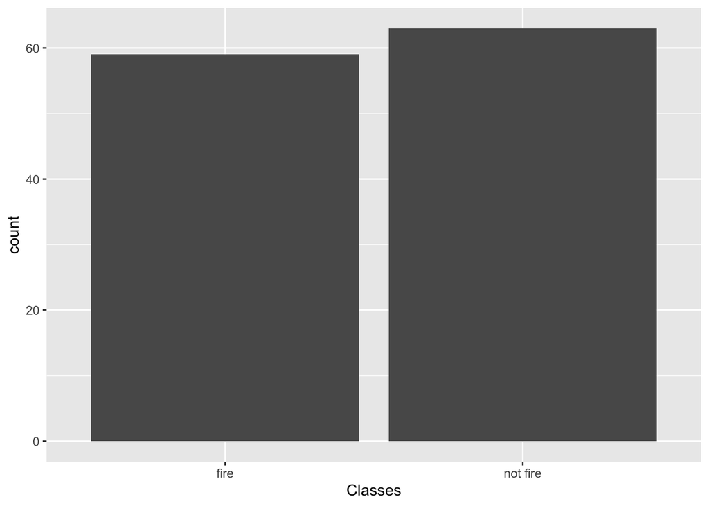

```r
# Region 1 Classes
ggplot(data = forestfireregion1) + geom_bar(mapping = aes(x = Classes))
```

```r
# Frequency of rain and temperature to understand them better
as.data.frame(table(forestfireregion1$Temperature))
```

```
##    Var1 Freq
## 1    22    2
## 2    24    1
## 3    25    6
## 4    26    4
## 5    27    4
## 6    28    7
## 7    29   11
## 8    30   10
## 9    31   18
## 10   32   14
## 11   33   13
## 12   34    7
## 13   35   15
## 14   36    9
## 15   37    1
```

```r
as.data.frame(table(forestfireregion1$Rain))
```

```
##    Var1 Freq
## 1     0   66
## 2   0.1    9
## 3   0.2    2
## 4   0.3    8
## 5   0.4    5
## 6   0.5    2
## 7   0.6    4
## 8   0.7    4
## 9   0.8    1
## 10  0.9    1
## 11    1    2
## 12  1.2    2
## 13  1.3    1
## 14  1.4    2
## 15  1.8    3
## 16  2.5    1
## 17  3.1    1
## 18  3.8    1
## 19  4.6    1
## 20  5.8    1
## 21  7.2    1
## 22  8.3    1
## 23 10.1    1
## 24 13.1    1
## 25 16.8    1
```

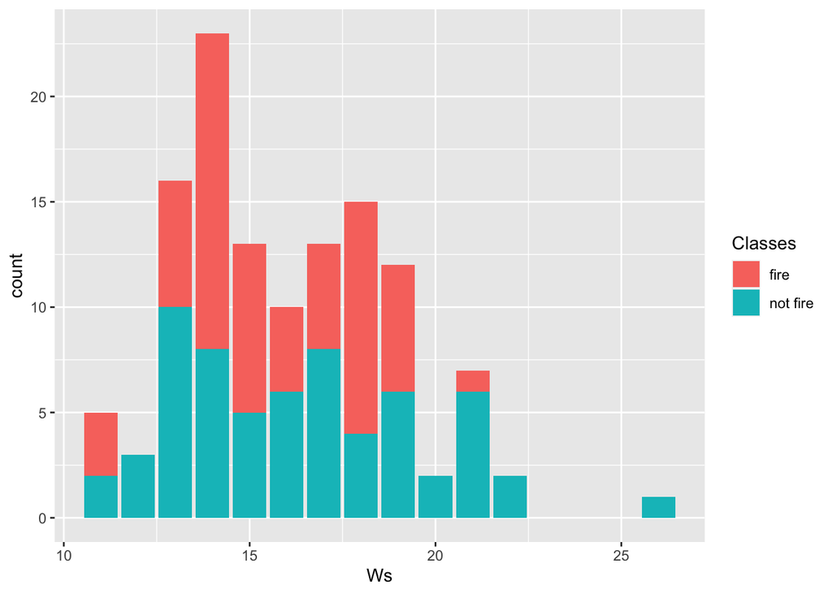

```r
# Temperature has most values concentrated in categories 31, 32, 33 and 35. Only a few observations made for categories 22, 24 and 37.

# Rain has most values concentrated in categories 0, 0.1 and 0.3. There are quite a lot of observations with less frequencies.

# Classes compared with Wind Speed
ggplot(data = forestfireregion1, aes(x = Ws)) +
  geom_bar(aes(fill = Classes))
```

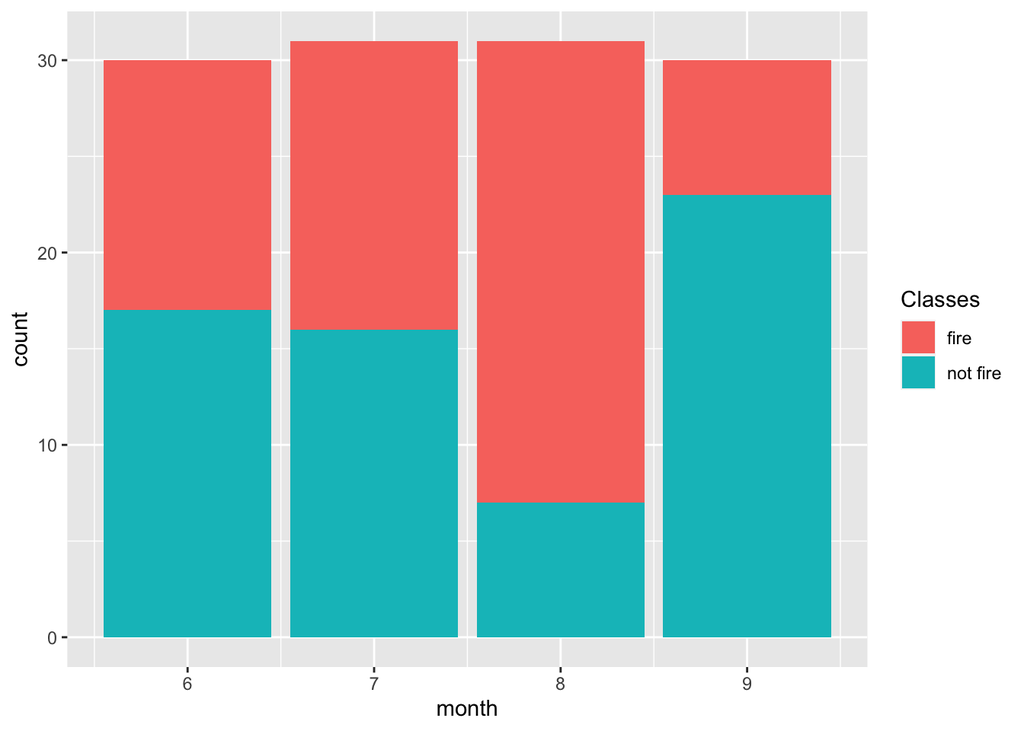

```r
# Classes per Month
ggplot(data = forestfireregion1, aes(x = month)) +
  geom_bar(aes(fill = Classes))
```

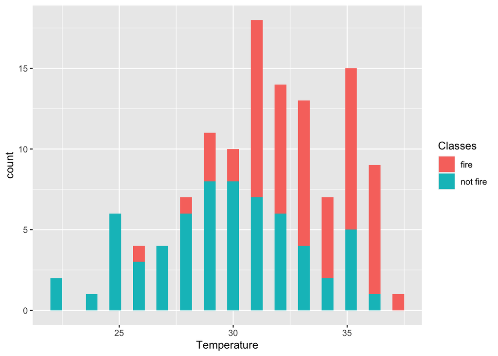

```r
# Temperature vs Classes
ggplot(data = forestfireregion1, aes(x = Temperature)) +geom_histogram(aes(fill = Classes),bins = 30)
```

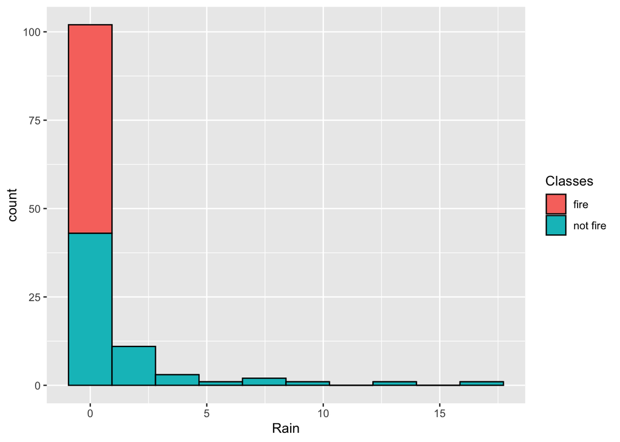

```r
# Rain vs Fire
ggplot(data = forestfireregion1, aes(x = Rain)) + geom_histogram(aes(fill = Classes), bins =10, color = "black")
```

##### The Chances of fire are greater when less Rain Precipitation

**EDA For Temperature**

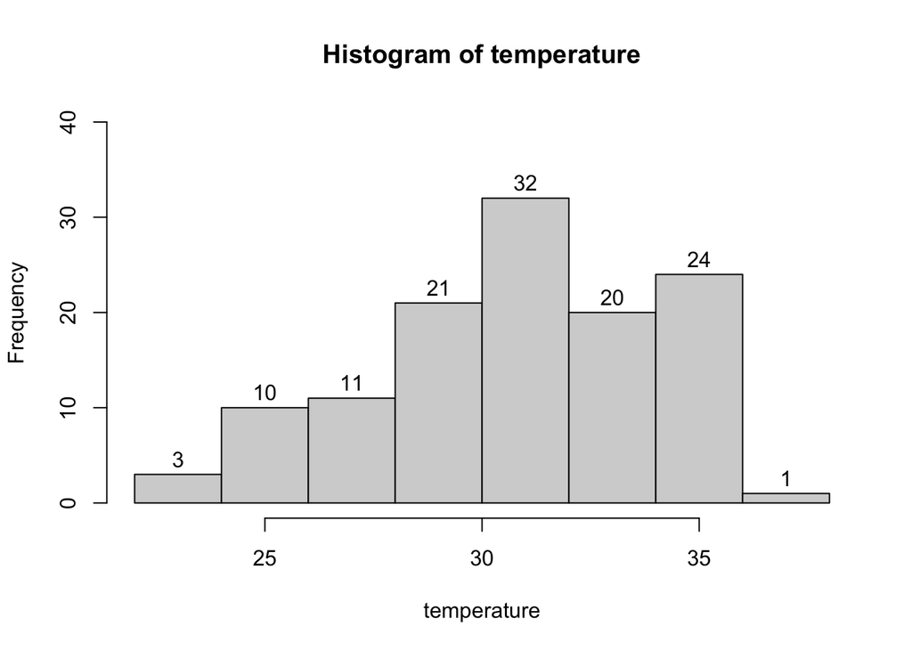

```r
temperature=forestfireregion1$Temperature
h1=hist(temperature,ylim=c(0,40))
text(h1$mids,h1$counts,labels=h1$counts, adj=c(0.5, -0.5))
```

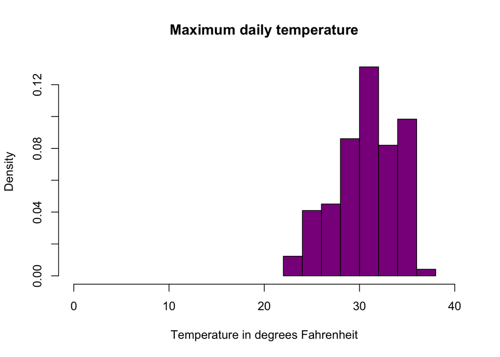

```r
hist(temperature,main="Maximum daily temperature",xlab="Temperature in degrees Fahrenheit",xlim=c(0,40),col="darkmagenta",freq=FALSE)
```

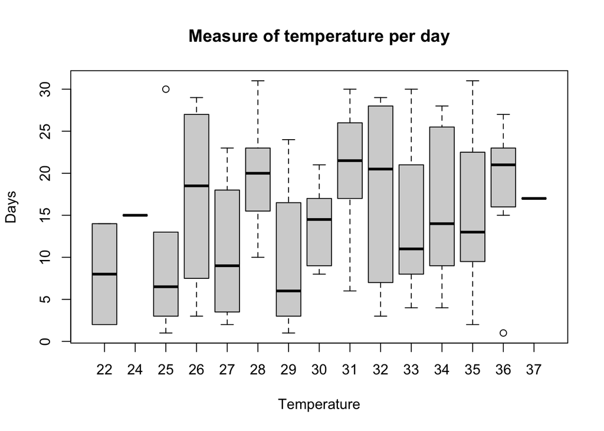

```r
boxplot(day~Temperature,data=forestfireregion1,main="Measure of temperature per day",xlab="Temperature",ylab="Days")
```

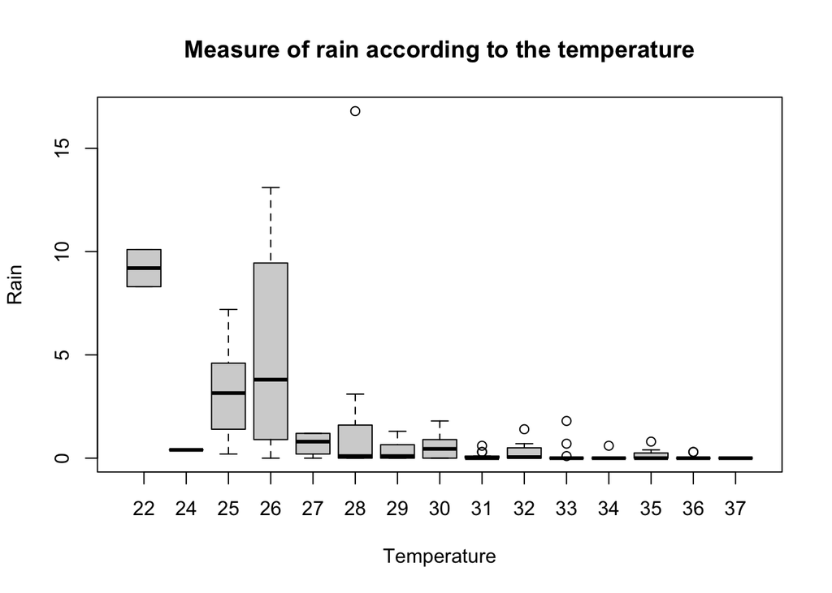

```r
boxplot(Rain~Temperature,data=forestfireregion1,main="Measure of rain according to the temperature",xlab="Temperature",ylab="Rain")
```

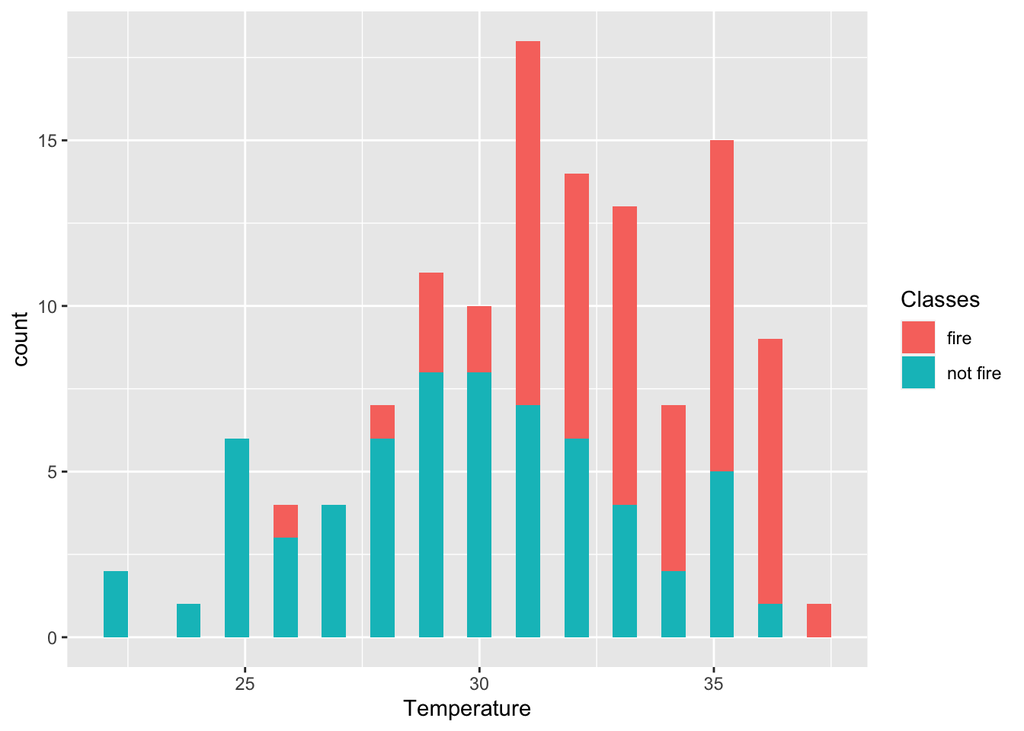

```r
ggplot(data = forestfireregion1, aes(x = Temperature)) +geom_histogram(aes(fill = Classes),bins = 30)
```

**EDA For Wind Speed**

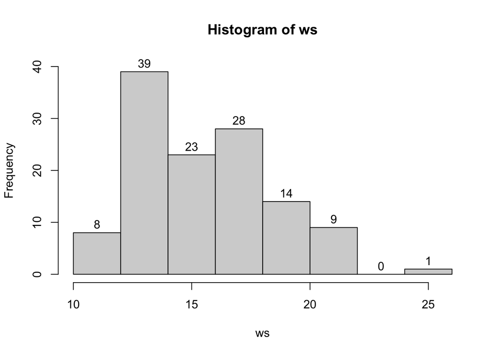

```r
ws=forestfireregion1$Ws
h1=hist(ws,ylim=c(0,40))
text(h1$mids,h1$counts,labels=h1$counts, adj=c(0.5, -0.5))
```

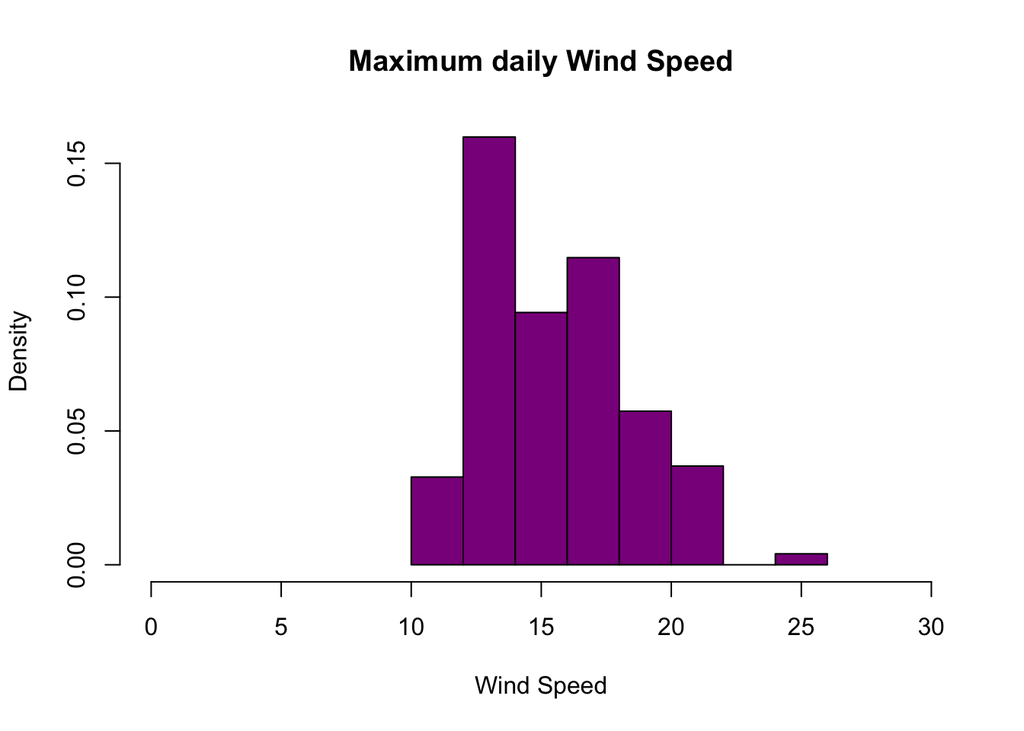

```r
hist(ws,main="Maximum daily Wind Speed",xlab="Wind Speed",xlim=c(0,30),col="darkmagenta",freq=FALSE)
```

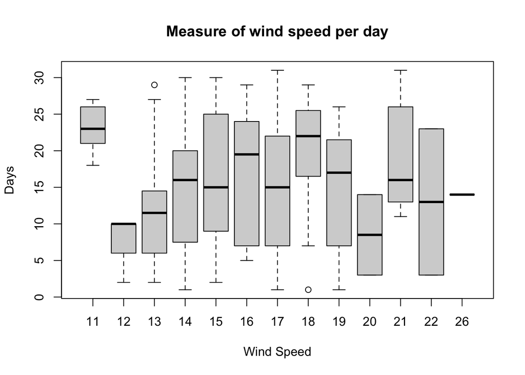

```r
boxplot(day~Ws,data=forestfireregion1,main="Measure of wind speed per day",xlab="Wind Speed",ylab="Days")
```

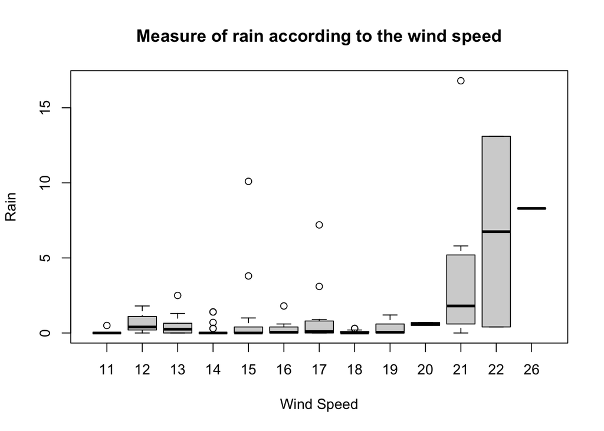

```r
boxplot(Rain~Ws,data=forestfireregion1,main="Measure of rain according to the wind speed",xlab="Wind Speed",ylab="Rain")
```

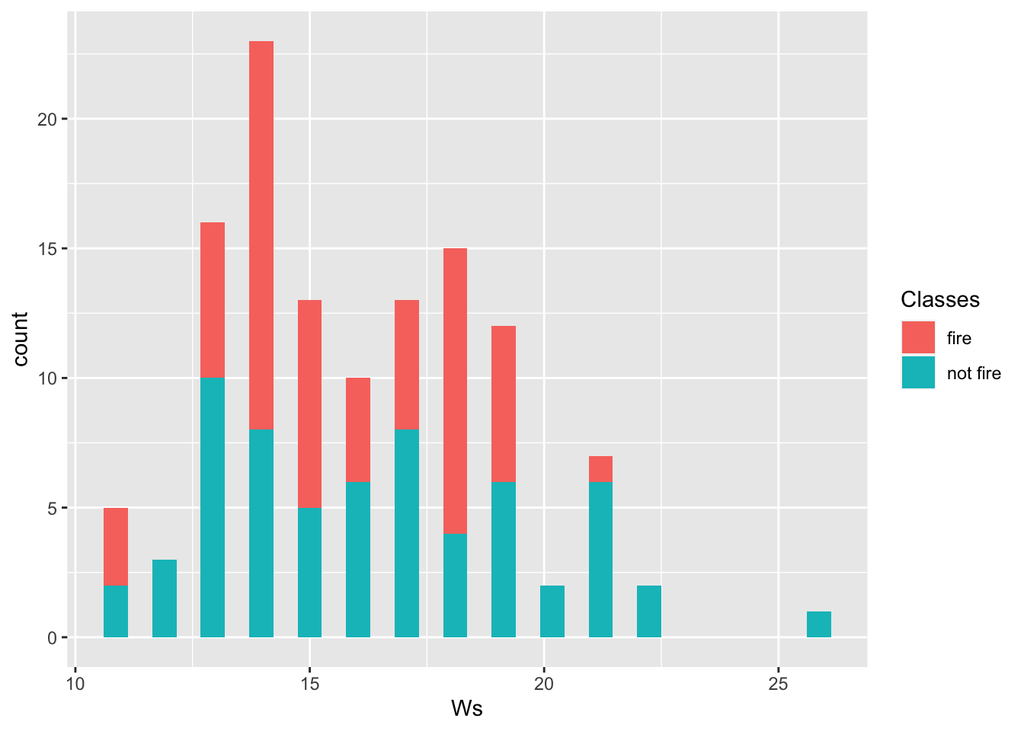

```r
ggplot(data = forestfireregion1, aes(x = Ws)) +geom_histogram(aes(fill = Classes),bins = 30)
```

# Data Analysis

## QQplot

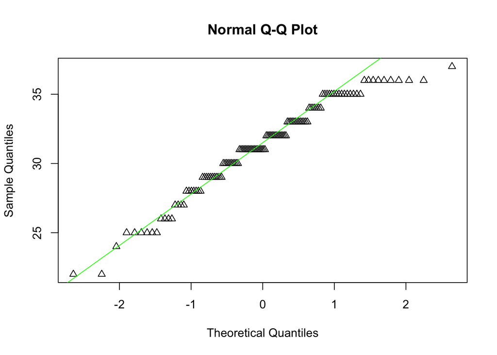

```r
qqnorm(forestfireregion1$Temperature, pch=2)
qqline(forestfireregion1$Temperature, col ="green")
```

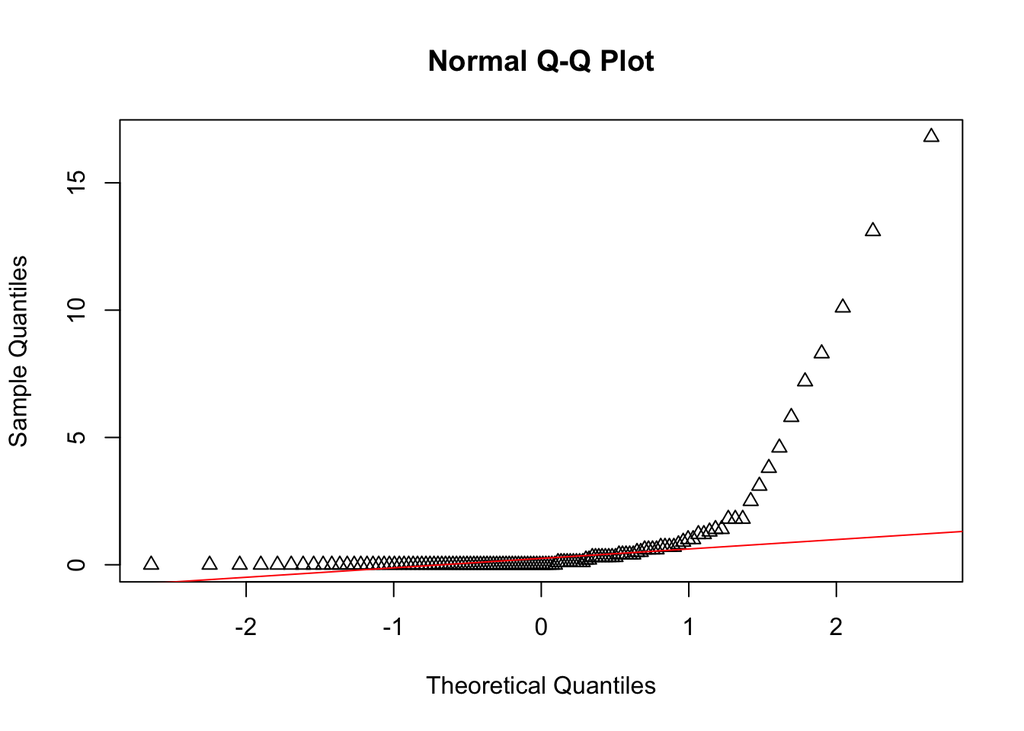

```r
qqnorm(forestfireregion1$Rain, pch=2)
qqline(forestfireregion1$Rain, col ="red")
```

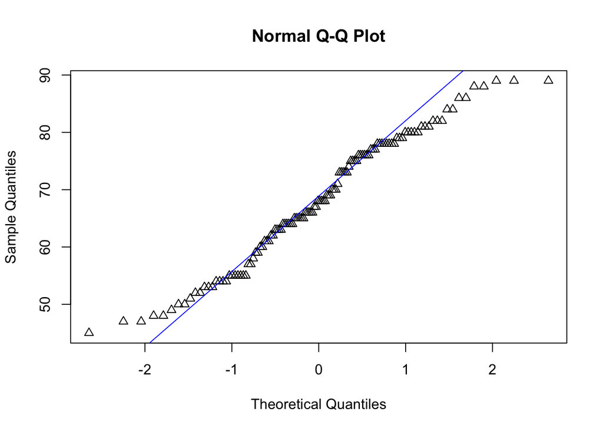

```r
qqnorm(forestfireregion1$RH, pch=2)
qqline(forestfireregion1$RH, col ="blue")
```

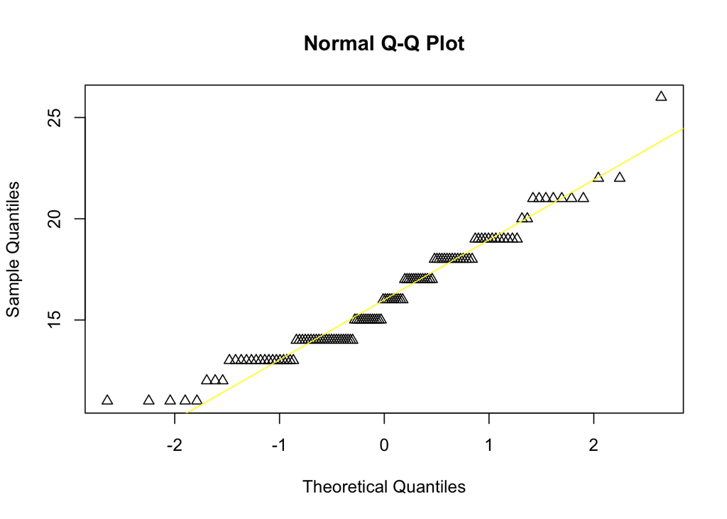

```r
qqnorm(forestfireregion1$Ws, pch=2)
qqline(forestfireregion1$Ws, col ="yellow")
```

# Hypothesis Testing:

Consider the hypothesis as given below,

H0: 𝜎(junemonth$Rain) = 𝜎(julymonth$Rain)

H1: 𝜎(junemonth$Rain) ≠ 𝜎(julymonth$Rain)

```r
junemonth=subset.data.frame(forestfireregion1,forestfireregion1$month==6)
summary(junemonth)
```

```
##       day            month        year       Temperature          RH
##  Min.   : 1.00   Min.   :6   Min.   :2012   Min.   :25.00   Min.   :47.00
##  1st Qu.: 8.25   1st Qu.:6   1st Qu.:2012   1st Qu.:28.25   1st Qu.:61.25
##  Median :15.50   Median :6   Median :2012   Median :30.00   Median :70.00
##  Mean   :15.50   Mean   :6   Mean   :2012   Mean   :29.80   Mean   :70.40
##  3rd Qu.:22.75   3rd Qu.:6   3rd Qu.:2012   3rd Qu.:31.00   3rd Qu.:80.00
##  Max.   :30.00   Max.   :6   Max.   :2012   Max.   :34.00   Max.   :89.00
##        Ws             Rain              FFMC            DMC
##  Min.   :12.00   Min.   : 0.0000   Min.   :28.60   Min.   : 1.10
##  1st Qu.:14.00   1st Qu.: 0.0000   1st Qu.:57.42   1st Qu.: 3.40
##  Median :15.50   Median : 0.0500   Median :79.50   Median : 6.85
##  Mean   :15.77   Mean   : 0.8167   Mean   :69.95   Mean   : 8.86
##  3rd Qu.:17.75   3rd Qu.: 0.4750   3rd Qu.:85.55   3rd Qu.:12.40
##  Max.   :22.00   Max.   :13.1000   Max.   :89.10   Max.   :25.50
##        DC             ISI            BUI             FWI
##  Min.   : 6.90   Min.   :0.00   Min.   : 1.60   Min.   : 0.000
##  1st Qu.: 7.85   1st Qu.:0.75   1st Qu.: 3.90   1st Qu.: 0.325
##  Median :31.05   Median :2.30   Median : 9.05   Median : 1.800
##  Mean   :36.34   Mean   :2.93   Mean   :10.88   Mean   : 3.847
##  3rd Qu.:55.42   3rd Qu.:5.40   3rd Qu.:15.57   3rd Qu.: 7.100
##  Max.   :92.80   Max.   :9.20   Max.   :29.70   Max.   :15.000
##    Classes
##  Length:30
##  Class :character
##  Mode  :character
##
##
##
```

```r
julymonth=subset.data.frame(forestfireregion1,forestfireregion1$month==7)
summary(julymonth)
```

```
##       day           month        year       Temperature          RH
##  Min.   : 1.0   Min.   :7   Min.   :2012   Min.   :27.00   Min.   :48.00
##  1st Qu.: 8.5   1st Qu.:7   1st Qu.:2012   1st Qu.:30.50   1st Qu.:65.00
##  Median :16.0   Median :7   Median :2012   Median :32.00   Median :69.00
##  Mean   :16.0   Mean   :7   Mean   :2012   Mean   :31.84   Mean   :69.58
##  3rd Qu.:23.5   3rd Qu.:7   3rd Qu.:2012   3rd Qu.:33.00   3rd Qu.:76.00
##  Max.   :31.0   Max.   :7   Max.   :2012   Max.   :36.00   Max.   :81.00
##        Ws             Rain             FFMC            DMC
##  Min.   :13.00   Min.   :0.0000   Min.   :55.70   Min.   : 2.40
##  1st Qu.:14.00   1st Qu.:0.0000   1st Qu.:71.30   1st Qu.: 7.65
##  Median :16.00   Median :0.0000   Median :81.40   Median : 9.70
##  Mean   :16.35   Mean   :0.2258   Mean   :78.06   Mean   :12.14
##  3rd Qu.:18.50   3rd Qu.:0.3000   3rd Qu.:85.75   3rd Qu.:14.45
##  Max.   :22.00   Max.   :1.4000   Max.   :90.30   Max.   :31.90
##        DC              ISI              BUI             FWI
##  Min.   :  8.30   Min.   : 0.700   Min.   : 2.80   Min.   : 0.300
##  1st Qu.: 20.80   1st Qu.: 1.400   1st Qu.: 8.20   1st Qu.: 0.850
##  Median : 40.40   Median : 2.800   Median :12.50   Median : 3.400
##  Mean   : 54.32   Mean   : 3.623   Mean   :15.48   Mean   : 5.229
##  3rd Qu.: 79.80   3rd Qu.: 5.400   3rd Qu.:20.10   3rd Qu.: 8.400
##  Max.   :145.70   Max.   :10.000   Max.   :41.20   Max.   :15.700
##    Classes
##  Length:31
##  Class :character
##  Mode  :character
##
##
##
```

```r
s1=sd(junemonth$Rain)
s2=sd(julymonth$Rain)
n1=length(junemonth$Rain)
n2=length(julymonth$Rain)
fvalue=s1^2/s2^2
fvalue
```

```
## [1] 39.04855
```

```r
alpha=0.05
f1=qf(alpha/2,n1-1,n2-1)
f1
```

```
## [1] 0.4779391
```

```r
f2=qf(1-alpha/2,n1-1,n2-1)
f2
```

```
## [1] 2.082661
```

```r
var.test(julymonth$Rain,junemonth$Rain,alternative = "two.sided",conf.level = 0.95)
```

```
##
##  F test to compare two variances
##
## data:  julymonth$Rain and junemonth$Rain
## F = 0.025609, num df = 30, denom df = 29, p-value < 2.2e-16
## alternative hypothesis: true ratio of variances is not equal to 1
## 95 percent confidence interval:
##  0.01223961 0.05333515
## sample estimates:
## ratio of variances
##         0.02560914
```

##### The variances are not equal because the p value is much lesser than significance level and the fvalue doesn’t lie between f1 and f2, hence we reject the hypothesis.

## For unknown mean and unequal variances

> Consider the hypothesis as given below,

H0: 𝝻(junemonth$Rain) = 𝝻(julymonth$Rain)

H1: 𝝻(junemonth$Rain) ≠ 𝝻(julymonth$Rain)

```r
t.test(junemonth$Rain,julymonth$Rain,var.equal = FALSE,conf.level = 0.95)
```

```
##
##  Welch Two Sample t-test
##
## data:  junemonth$Rain and julymonth$Rain
## t = 1.3123, df = 30.437, p-value = 0.1992
## alternative hypothesis: true difference in means is not equal to 0
## 95 percent confidence interval:
##  -0.3281092  1.5098296
## sample estimates:
## mean of x mean of y
## 0.8166667 0.2258065
```

##### We are using t.test because we have two means and the variance are unknown and are not equal. The p-value is greater than alpha i.e., 0.05. So we can accept the null hypothesis H0 and agree that the increase of total rain in the month of June is equal to the increase of total rain in the month of July. <h/5>

## Hypothesis testing on one sample:

> Consider the hypothesis as given below,

H0: 𝝻(RH) = 68

H1: 𝝻(RH) ≠ 68

```r
fr<- forestfireregion1 %>% subset(Classes == "fire", select= RH)
nofr <- forestfireregion1 %>% subset(Classes == "not fire", select= RH)
t.test(nofr, mu = 68)
```

```
##
##  One Sample t-test
##
## data:  nofr
## t = 2.7857, df = 62, p-value = 0.007077
## alternative hypothesis: true mean is not equal to 68
## 95 percent confidence interval:
##  69.13861 74.92488
## sample estimates:
## mean of x
##  72.03175
```

##### According to p value we should reject H0, when there is no fire average relative humidity would not be equal to 68.

## Corelation

##### r<0.3, weak correlation 0.3<r<0.7, moderate correlation r>0.7, high correlation

**Multiple Regression Testing on Region 1**

```r
i <- sample(2, nrow(forestfireregion1), replace=TRUE, prob=c(0.8, 0.2))
Region1Training = forestfireregion1[i==1,]
Region1Testing = forestfireregion1[i==2,]
```

## Correlation of training dataset attributes except Classes.

```r
cor(subset(Region1Training, select=-Classes))
```

```
##                      day        month year Temperature         RH           Ws
## day          1.000000000  0.015883220   NA  0.27755491 -0.2830772 -0.008464143
## month        0.015883220  1.000000000   NA  0.02950127 -0.1112714 -0.038995009
## year                  NA           NA    1          NA         NA           NA
## Temperature  0.277554910  0.029501269   NA  1.00000000 -0.6770554 -0.064282032
## RH          -0.283077162 -0.111271446   NA -0.67705541  1.0000000  0.189481439
## Ws          -0.008464143 -0.038995009   NA -0.06428203  0.1894814  1.000000000
## Rain        -0.283413246  0.091708608   NA -0.49651058  0.3373589  0.219331027
## FFMC         0.381812483 -0.007737872   NA  0.75189652 -0.6299032 -0.112340127
## DMC          0.580373547  0.020336570   NA  0.57071645 -0.3504859  0.081218405
## DC           0.604802815  0.024341092   NA  0.56974879 -0.3062239  0.146950093
## ISI          0.422496477  0.022076230   NA  0.68093460 -0.5684200  0.025299894
## BUI          0.593986733  0.019248019   NA  0.57504474 -0.3384116  0.105722135
## FWI          0.506344795  0.031780937   NA  0.63410447 -0.4664376  0.079802235
##                    Rain         FFMC         DMC          DC         ISI
## day         -0.28341325  0.381812483  0.58037355  0.60480281  0.42249648
## month        0.09170861 -0.007737872  0.02033657  0.02434109  0.02207623
## year                 NA           NA          NA          NA          NA
## Temperature -0.49651058  0.751896516  0.57071645  0.56974879  0.68093460
## RH           0.33735893 -0.629903241 -0.35048594 -0.30622392 -0.56842001
## Ws           0.21933103 -0.112340127  0.08121841  0.14695009  0.02529989
## Rain         1.00000000 -0.625439818 -0.29765999 -0.28648663 -0.38141290
## FFMC        -0.62543982  1.000000000  0.59970186  0.55635216  0.78351193
## DMC         -0.29765999  0.599701856  1.00000000  0.96260047  0.75278786
## DC          -0.28648663  0.556352158  0.96260047  1.00000000  0.71067664
## ISI         -0.38141290  0.783511926  0.75278786  0.71067664  1.00000000
## BUI         -0.29560313  0.589173167  0.99560178  0.98262346  0.74703202
## FWI         -0.30153776  0.668004179  0.90508667  0.86558784  0.94408526
##                     BUI         FWI
## day          0.59398673  0.50634479
## month        0.01924802  0.03178094
## year                 NA          NA
## Temperature  0.57504474  0.63410447
## RH          -0.33841158 -0.46643760
## Ws           0.10572213  0.07980224
## Rain        -0.29560313 -0.30153776
## FFMC         0.58917317  0.66800418
## DMC          0.99560178  0.90508667
## DC           0.98262346  0.86558784
## ISI          0.74703202  0.94408526
## BUI          1.00000000  0.90162293
## FWI          0.90162293  1.00000000
```

**Forward Step Regression Testing ~ Temperature**

```r
intercept_only <- lm(Temperature ~ 1, data=Region1Training[,1:14])
all <- lm(Temperature~., data=Region1Training[,1:14])
forward <- stepAIC (intercept_only, direction='forward',scope = formula(all))
```

```
## Start:  AIC=243.99
## Temperature ~ 1
##
##           Df Sum of Sq     RSS    AIC
## + FFMC     1    618.41  475.44 161.01
## + ISI      1    507.19  586.66 182.45
## + RH       1    501.43  592.43 183.44
## + FWI      1    439.83  654.03 193.53
## + BUI      1    361.71  732.14 205.04
## + DMC      1    356.29  737.57 205.79
## + DC       1    355.08  738.77 205.96
## + Classes  1    276.94  816.91 216.22
## + Rain     1    269.66  824.19 217.12
## + day      1     84.27 1009.59 237.82
## <none>                 1093.85 243.99
## + Ws       1      4.52 1089.33 245.57
## + month    1      0.95 1092.90 245.91
##
## Step:  AIC=161.01
## Temperature ~ FFMC
##
##           Df Sum of Sq    RSS    AIC
## + RH       1    75.046 400.40 145.48
## + DC       1    36.327 439.12 154.90
## + FWI      1    34.331 441.11 155.36
## + BUI      1    29.214 446.23 156.54
## + DMC      1    24.517 450.93 157.61
## + ISI      1    23.882 451.56 157.75
## <none>                 475.44 161.01
## + Classes  1     8.128 467.32 161.25
## + month    1     1.365 474.08 162.71
## + Rain     1     1.237 474.21 162.74
## + Ws       1     0.451 474.99 162.91
## + day      1     0.116 475.33 162.98
##
## Step:  AIC=145.48
## Temperature ~ FFMC + RH
##
##           Df Sum of Sq    RSS    AIC
## + DC       1    44.042 356.36 135.60
```

[output cut: 49 more lines]

```
## + FWI      1    0.0685 319.88 130.58
## + month    1    0.0340 319.92 130.59
## + ISI      1    0.0008 319.95 130.60
##
## Step:  AIC=128.11
## Temperature ~ FFMC + RH + DC + day + Rain + DMC
##
##           Df Sum of Sq    RSS    AIC
## <none>                 312.23 128.11
## + Classes  1   1.86582 310.36 129.50
## + FWI      1   1.30150 310.93 129.69
## + BUI      1   0.93169 311.30 129.81
## + ISI      1   0.34242 311.88 130.00
## + month    1   0.06320 312.17 130.09
## + Ws       1   0.00021 312.23 130.11
```

```r
forward$anova
```

```
## Stepwise Model Path
## Analysis of Deviance Table
##
## Initial Model:
## Temperature ~ 1
##
## Final Model:
## Temperature ~ FFMC + RH + DC + day + Rain + DMC
##
##
##     Step Df   Deviance Resid. Df Resid. Dev      AIC
## 1                            101  1093.8529 243.9939
## 2 + FFMC  1 618.407978       100   475.4450 161.0064
## 3   + RH  1  75.045758        99   400.3992 145.4839
## 4   + DC  1  44.042349        98   356.3569 135.5979
## 5  + day  1  25.097823        97   331.2590 130.1486
## 6 + Rain  1  11.309140        96   319.9499 128.6055
## 7  + DMC  1   7.722162        95   312.2277 128.1135
```

```r
summary(forward)
```

```
##
## Call:
## lm(formula = Temperature ~ FFMC + RH + DC + day + Rain + DMC,
##     data = Region1Training[, 1:14])
##
## Residuals:
##     Min      1Q  Median      3Q     Max
## -4.7851 -1.3831  0.1228  1.2575  4.1417
##
## Coefficients:
##             Estimate Std. Error t value Pr(>|t|)
## (Intercept) 33.81112    2.66007  12.711  < 2e-16 ***
## FFMC         0.07117    0.02167   3.284  0.00143 **
## RH          -0.11570    0.02085  -5.550 2.58e-07 ***
## DC           0.04227    0.01314   3.216  0.00178 **
## day         -0.07736    0.02551  -3.032  0.00313 **
## Rain        -0.21163    0.12457  -1.699  0.09262 .
## DMC         -0.09414    0.06142  -1.533  0.12864
## ---
## Signif. codes:  0 '***' 0.001 '**' 0.01 '*' 0.05 '.' 0.1 ' ' 1
##
## Residual standard error: 1.813 on 95 degrees of freedom
## Multiple R-squared:  0.7146, Adjusted R-squared:  0.6965
## F-statistic: 39.64 on 6 and 95 DF,  p-value: < 2.2e-16
```

```r
ypred_forward = predict(object = forward, newdata = Region1Testing[,1:14])
MAE(y_pred = ypred_forward, y_true = Region1Testing$Temperature)
```

```
## [1] 2.366033
```

```r
MSE(y_pred = ypred_forward, y_true = Region1Testing$Temperature)
```

```
## [1] 8.031958
```

**Backwards Step Regression Testing ~ Temperature**

```r
backward <- stepAIC (all, direction='backward')
```

```
## Start:  AIC=135.99
## Temperature ~ day + month + year + RH + Ws + Rain + FFMC + DMC +
##     DC + ISI + BUI + FWI + Classes
##
##
## Step:  AIC=135.99
## Temperature ~ day + month + RH + Ws + Rain + FFMC + DMC + DC +
##     ISI + BUI + FWI + Classes
##
##           Df Sum of Sq    RSS    AIC
## - BUI      1     0.012 299.86 133.99
## - month    1     0.261 300.11 134.07
## - Ws       1     0.538 300.38 134.17
## - DMC      1     1.271 301.12 134.42
## - DC       1     2.404 302.25 134.80
## - ISI      1     3.541 303.39 135.18
## - Classes  1     4.646 304.49 135.55
## - Rain     1     5.735 305.58 135.92
## <none>                 299.84 135.99
## - FWI      1     6.001 305.85 136.01
## - day      1    27.277 327.12 142.87
## - FFMC     1    30.798 330.64 143.96
## - RH       1    50.616 350.46 149.90
##
## Step:  AIC=133.99
## Temperature ~ day + month + RH + Ws + Rain + FFMC + DMC + DC +
##     ISI + FWI + Classes
##
##           Df Sum of Sq    RSS    AIC
## - month    1     0.277 300.13 132.08
## - Ws       1     0.532 300.39 132.17
## - ISI      1     3.787 303.64 133.27
## - Classes  1     4.657 304.51 133.56
## - Rain     1     5.744 305.60 133.93
## <none>                 299.86 133.99
## - FWI      1     6.584 306.44 134.21
## - DMC      1    14.487 314.34 136.80
## - day      1    27.352 327.21 140.89
## - DC       1    30.444 330.30 141.85
## - FFMC     1    31.384 331.24 142.14
```

[output cut: 58 more lines]

```
## - day      1    30.191 340.55 136.97
## - DC       1    33.009 343.37 137.81
## - RH       1    86.275 396.64 152.52
##
## Step:  AIC=128.11
## Temperature ~ day + RH + Rain + FFMC + DMC + DC
##
##        Df Sum of Sq    RSS    AIC
## <none>              312.23 128.11
## - DMC   1     7.722 319.95 128.61
## - Rain  1     9.486 321.71 129.17
## - day   1    30.218 342.45 135.54
## - DC    1    33.989 346.22 136.65
## - FFMC  1    35.446 347.67 137.08
## - RH    1   101.237 413.46 154.76
```

```r
backward$anova
```

```
## Stepwise Model Path
## Analysis of Deviance Table
##
## Initial Model:
## Temperature ~ day + month + year + RH + Ws + Rain + FFMC + DMC +
##     DC + ISI + BUI + FWI + Classes
##
## Final Model:
## Temperature ~ day + RH + Rain + FFMC + DMC + DC
##
##
##        Step Df   Deviance Resid. Df Resid. Dev      AIC
## 1                                89   299.8448 135.9858
## 2    - year  0 0.00000000        89   299.8448 135.9858
## 3     - BUI  1 0.01164607        90   299.8565 133.9898
## 4   - month  1 0.27731014        91   300.1338 132.0841
## 5      - Ws  1 0.48171225        92   300.6155 130.2476
## 6     - ISI  1 3.92538662        93   304.5409 129.5709
## 7     - FWI  1 5.82104194        94   310.3619 129.5022
## 8 - Classes  1 1.86581516        95   312.2277 128.1135
```

```r
summary(backward)
```

```
##
## Call:
## lm(formula = Temperature ~ day + RH + Rain + FFMC + DMC + DC,
##     data = Region1Training[, 1:14])
##
## Residuals:
##     Min      1Q  Median      3Q     Max
## -4.7851 -1.3831  0.1228  1.2575  4.1417
##
## Coefficients:
##             Estimate Std. Error t value Pr(>|t|)
## (Intercept) 33.81112    2.66007  12.711  < 2e-16 ***
## day         -0.07736    0.02551  -3.032  0.00313 **
## RH          -0.11570    0.02085  -5.550 2.58e-07 ***
## Rain        -0.21163    0.12457  -1.699  0.09262 .
## FFMC         0.07117    0.02167   3.284  0.00143 **
## DMC         -0.09414    0.06142  -1.533  0.12864
## DC           0.04227    0.01314   3.216  0.00178 **
## ---
## Signif. codes:  0 '***' 0.001 '**' 0.01 '*' 0.05 '.' 0.1 ' ' 1
##
## Residual standard error: 1.813 on 95 degrees of freedom
## Multiple R-squared:  0.7146, Adjusted R-squared:  0.6965
## F-statistic: 39.64 on 6 and 95 DF,  p-value: < 2.2e-16
```

```r
ypred_backward = predict(object = backward, newdata = Region1Testing[,1:14])
MAE(y_pred = ypred_backward, y_true = Region1Testing$Temperature)
```

```
## [1] 2.366033
```

```r
MSE(y_pred = ypred_backward, y_true = Region1Testing$Temperature)
```

```
## [1] 8.031958
```

## Response as Wind

**Forward Step Regression Testing ~ Wind Speed**

```r
intercept_only <- lm( Ws~ 1, data=Region1Training[,1:14])
all <- lm(Ws~., data=Region1Testing[,1:14])
forward <- stepAIC (intercept_only, direction='forward',scope = formula(all))
```

```
## Start:  AIC=201.69
## Ws ~ 1
##
##               Df Sum of Sq    RSS    AIC
## + Rain         1    34.758 687.76 198.66
## + RH           1    25.941 696.58 199.96
## + DC           1    15.602 706.92 201.47
## <none>                     722.52 201.69
## + FFMC         1     9.118 713.40 202.40
## + BUI          1     8.076 714.44 202.55
## + Classes      1     7.013 715.51 202.70
## + DMC          1     4.766 717.75 203.02
## + FWI          1     4.601 717.92 203.04
## + Temperature  1     2.986 719.53 203.27
## + month        1     1.099 721.42 203.54
## + ISI          1     0.462 722.06 203.63
## + day          1     0.052 722.47 203.69
##
## Step:  AIC=198.66
## Ws ~ Rain
##
##               Df Sum of Sq    RSS    AIC
## + DC           1    34.641 653.12 195.39
## + BUI          1    23.030 664.73 197.19
## + DMC          1    17.015 670.75 198.11
## + FWI          1    16.927 670.83 198.12
## <none>                     687.76 198.66
## + RH           1    10.874 676.89 199.04
## + ISI          1    10.037 677.72 199.16
## + month        1     2.546 685.22 200.29
## + day          1     2.265 685.50 200.33
## + Temperature  1     1.909 685.85 200.38
## + FFMC         1     0.732 687.03 200.56
## + Classes      1     0.378 687.38 200.61
##
## Step:  AIC=195.39
## Ws ~ Rain + DC
##
##               Df Sum of Sq    RSS    AIC
## + DMC          1   28.9115 624.21 192.77
```

[output cut: 24 more lines]

```
## + ISI          1    0.6646 623.54 194.67
##
## Step:  AIC=192.4
## Ws ~ Rain + DC + DMC + RH
##
##               Df Sum of Sq    RSS    AIC
## <none>                     609.83 192.40
## + FWI          1    8.1907 601.64 193.02
## + ISI          1    8.0926 601.74 193.03
## + Classes      1    5.5178 604.31 193.47
## + day          1    3.9690 605.86 193.73
## + BUI          1    3.5424 606.29 193.80
## + month        1    1.9120 607.92 194.08
## + FFMC         1    1.4281 608.40 194.16
## + Temperature  1    0.8906 608.94 194.25
```

```r
forward$anova
```

```
## Stepwise Model Path
## Analysis of Deviance Table
##
## Initial Model:
## Ws ~ 1
##
## Final Model:
## Ws ~ Rain + DC + DMC + RH
##
##
##     Step Df Deviance Resid. Df Resid. Dev      AIC
## 1                          101   722.5196 201.6927
## 2 + Rain  1 34.75760       100   687.7620 198.6639
## 3   + DC  1 34.64122        99   653.1208 195.3925
## 4  + DMC  1 28.91153        98   624.2093 192.7743
## 5   + RH  1 14.37675        97   609.8325 192.3976
```

```r
summary(forward)
```

```
##
## Call:
## lm(formula = Ws ~ Rain + DC + DMC + RH, data = Region1Training[,
##     1:14])
##
## Residuals:
##     Min      1Q  Median      3Q     Max
## -4.2734 -1.9029 -0.5631  1.8734  5.4375
##
## Coefficients:
##             Estimate Std. Error t value Pr(>|t|)
## (Intercept) 12.65048    1.75882   7.193 1.34e-10 ***
## Rain         0.31917    0.14243   2.241   0.0273 *
## DC           0.04437    0.01770   2.506   0.0139 *
## DMC         -0.14873    0.08281  -1.796   0.0756 .
## RH           0.03713    0.02455   1.512   0.1337
## ---
## Signif. codes:  0 '***' 0.001 '**' 0.01 '*' 0.05 '.' 0.1 ' ' 1
##
## Residual standard error: 2.507 on 97 degrees of freedom
## Multiple R-squared:  0.156,  Adjusted R-squared:  0.1212
## F-statistic: 4.481 on 4 and 97 DF,  p-value: 0.002297
```

```r
ypred_for <- predict(object = forward, newdata = Region1Testing[,1:14])
MAE(y_pred = ypred_for, y_true = Region1Testing$Ws)
```

```
## [1] 2.113813
```

```r
MSE(y_pred = ypred_for, y_true = Region1Testing$Ws)
```

```
## [1] 7.615777
```

**Backwards Step Regression Testing ~ Wind Speed**

```r
backward <- stepAIC (all, direction='backward')
```

```
## Start:  AIC=31.44
## Ws ~ day + month + year + Temperature + RH + Rain + FFMC + DMC +
##     DC + ISI + BUI + FWI + Classes
##
##
## Step:  AIC=31.44
## Ws ~ day + month + Temperature + RH + Rain + FFMC + DMC + DC +
##     ISI + BUI + FWI + Classes
##
##               Df Sum of Sq    RSS    AIC
## - RH           1     0.584 26.833 29.878
## - FWI          1     0.731 26.979 29.987
## - FFMC         1     0.754 27.003 30.004
## - Classes      1     0.825 27.073 30.056
## - DC           1     0.829 27.078 30.060
## - ISI          1     1.054 27.302 30.225
## - BUI          1     1.890 28.138 30.828
## - DMC          1     2.231 28.480 31.069
## <none>                     26.249 31.438
## - Rain         1     9.379 35.628 35.548
## - day          1    11.003 37.251 36.439
## - month        1    11.607 37.856 36.761
## - Temperature  1    41.792 68.040 48.487
##
## Step:  AIC=29.88
## Ws ~ day + month + Temperature + Rain + FFMC + DMC + DC + ISI +
##     BUI + FWI + Classes
##
##               Df Sum of Sq    RSS    AIC
## - FFMC         1     0.196 27.029 28.023
## - FWI          1     0.207 27.040 28.032
## - Classes      1     0.301 27.134 28.101
## - DC           1     0.467 27.300 28.223
## - ISI          1     0.473 27.306 28.227
## - BUI          1     1.306 28.139 28.828
## - DMC          1     1.649 28.482 29.071
## <none>                     26.833 29.878
## - day          1    10.596 37.429 34.534
## - month        1    12.983 39.815 35.770
## - Rain         1    15.630 42.463 37.058
```

[output cut: 46 more lines]

```
## - month        1    28.910  56.171 36.653
## - Temperature  1    83.314 110.575 50.199
##
## Step:  AIC=22.54
## Ws ~ day + month + Temperature + Rain + DMC + ISI + BUI
##
##               Df Sum of Sq     RSS    AIC
## <none>                      27.742 22.544
## - ISI          1     4.585  32.327 23.604
## - DMC          1     5.556  33.298 24.195
## - BUI          1     6.854  34.596 24.960
## - day          1    11.566  39.308 27.514
## - Rain         1    24.894  52.636 33.353
## - month        1    28.605  56.347 34.716
## - Temperature  1    87.700 115.442 49.061
```

```r
backward$anova
```

```
## Stepwise Model Path
## Analysis of Deviance Table
##
## Initial Model:
## Ws ~ day + month + year + Temperature + RH + Rain + FFMC + DMC +
##     DC + ISI + BUI + FWI + Classes
##
## Final Model:
## Ws ~ day + month + Temperature + Rain + DMC + ISI + BUI
##
##
##        Step Df   Deviance Resid. Df Resid. Dev      AIC
## 1                                 7   26.24865 31.43765
## 2    - year  0 0.00000000         7   26.24865 31.43765
## 3      - RH  1 0.58427891         8   26.83293 29.87795
## 4    - FFMC  1 0.19596795         9   27.02890 28.02349
## 5     - FWI  1 0.01160649        10   27.04050 26.03207
## 6 - Classes  1 0.22025106        11   27.26076 24.19432
## 7      - DC  1 0.48129293        12   27.74205 22.54434
```

```r
summary(backward)
```

```
##
## Call:
## lm(formula = Ws ~ day + month + Temperature + Rain + DMC + ISI +
##     BUI, data = Region1Testing[, 1:14])
##
## Residuals:
##     Min      1Q  Median      3Q     Max
## -3.3283 -0.3348 -0.0136  0.2386  2.2866
##
## Coefficients:
##             Estimate Std. Error t value Pr(>|t|)
## (Intercept) 60.59307    7.31566   8.283 2.63e-06 ***
## day         -0.15150    0.06773  -2.237  0.04506 *
## month       -1.45188    0.41275  -3.518  0.00424 **
## Temperature -1.07292    0.17420  -6.159 4.88e-05 ***
## Rain         0.43980    0.13402   3.281  0.00656 **
## DMC         -0.66831    0.43111  -1.550  0.14705
## ISI          0.42518    0.30190   1.408  0.18441
## BUI          0.60594    0.35191   1.722  0.11075
## ---
## Signif. codes:  0 '***' 0.001 '**' 0.01 '*' 0.05 '.' 0.1 ' ' 1
##
## Residual standard error: 1.52 on 12 degrees of freedom
## Multiple R-squared:  0.8919, Adjusted R-squared:  0.8288
## F-statistic: 14.14 on 7 and 12 DF,  p-value: 6.253e-05
```

```r
ypred_bac <- predict(object = backward, newdata = Region1Testing[,1:14])
MAE(y_pred = ypred_bac,y_true = Region1Testing$Ws)
```

```
## [1] 0.7533298
```

```r
MSE(y_pred = ypred_bac,y_true = Region1Testing$Ws)
```

```
## [1] 1.387102
```

## Confidence and Predection Intervals

```r
fitLmtest1 <- lm(FFMC~ Ws, data=forestfireregion1)
new <- data.frame(Ws = 22)
predict(fitLmtest1 , new)
```

```
##        1
## 67.75645
```

```r
predict(fitLmtest1, new, interval="confidence")
```

```
##        fit      lwr      upr
## 1 67.75645 61.35258 74.16033
```

```r
predict(fitLmtest1, new, interval="prediction")
```

```
##        fit      lwr      upr
## 1 67.75645 36.84937 98.66353
```

## Confidence and Predection Intervals

```r
fitLmtest1 <- lm(FFMC~ Ws, data=forestfireregion1)
new <- data.frame(Ws = 22)
predict(fitLmtest1 , new)
```

```
##        1
## 67.75645
```

```r
predict(fitLmtest1, new, interval="confidence")
```

```
##        fit      lwr      upr
## 1 67.75645 61.35258 74.16033
```

```r
predict(fitLmtest1, new, interval="prediction")
```

```
##        fit      lwr      upr
## 1 67.75645 36.84937 98.66353
```

```r
fitLmtest2 <- lm(Temperature~ Rain, data=forestfireregion1)
new <- data.frame(Rain = 15)
predict(fitLmtest2 , new)
```

```
##        1
## 21.67907
```

```r
predict(fitLmtest2, new, interval="confidence")
```

```
##        fit      lwr      upr
## 1 21.67907 18.55489 24.80325
```

```r
predict(fitLmtest2, new, interval="prediction")
```

```
##        fit      lwr      upr
## 1 21.67907 15.12112 28.23703
```

```r
fitLmtest3 <- lm(RH ~ Rain, data=forestfireregion1)
new <- data.frame(Rain = 15)
predict(fitLmtest3 , new)
```

```
##        1
## 89.55115
```

```r
predict(fitLmtest3, new, interval="confidence")
```

```
##        fit      lwr      upr
## 1 89.55115 78.20467 100.8976
```

```r
predict(fitLmtest3, new, interval="prediction")
```

```
##        fit     lwr      upr
## 1 89.55115 65.7338 113.3685
```

## Association between the Numerical Variable and Categorical Variable

```r
aov1 <- aov(Rain ~Classes, data=forestfireregion1)
summary(aov1)
```

```
##              Df Sum Sq Mean Sq F value   Pr(>F)
## Classes       1   78.5   78.53   15.11 0.000167 ***
## Residuals   120  623.8    5.20
## ---
## Signif. codes:  0 '***' 0.001 '**' 0.01 '*' 0.05 '.' 0.1 ' ' 1
```

```r
aov2 <- aov(FFMC ~Classes, data=forestfireregion1)
summary(aov2)
```

```
##              Df Sum Sq Mean Sq F value Pr(>F)
## Classes       1  16198   16198   148.5 <2e-16 ***
## Residuals   120  13093     109
## ---
## Signif. codes:  0 '***' 0.001 '**' 0.01 '*' 0.05 '.' 0.1 ' ' 1
```

```r
aov2 <- aov(RH ~Classes, data=forestfireregion1)
summary(aov2)
```

```
##              Df Sum Sq Mean Sq F value   Pr(>F)
## Classes       1   2143  2143.5   19.92 1.83e-05 ***
## Residuals   120  12911   107.6
## ---
## Signif. codes:  0 '***' 0.001 '**' 0.01 '*' 0.05 '.' 0.1 ' ' 1
```

```r
aov2 <- aov(Temperature ~Classes, data=forestfireregion1)
summary(aov2)
```

```
##              Df Sum Sq Mean Sq F value   Pr(>F)
## Classes       1  330.6   330.6   39.53 5.42e-09 ***
## Residuals   120 1003.4     8.4
## ---
## Signif. codes:  0 '***' 0.001 '**' 0.01 '*' 0.05 '.' 0.1 ' ' 1
```

**`Thank you`!**